# ASSIGNMENT 1

## INITIALISATION

```python
import numpy as np
import matplotlib.pyplot as plt
import soundfile as sf
%matplotlib inline
%config InlineBackend.figure_format = 'retina'
```

## CREATING ARRAYS

```python
#1
testArray = np.random.randint(1,101,20)
print(testArray)
```

```
[  4  35  66  59  75  26  45 100  18  20  20  21  84  69  64  76  14  92
  64  48]
```

```python
#2
testArray = np.ones((5,5), dtype = int)
testArray[1:-1, 1:-1] = 0
print(testArray)
```

```
[[1 1 1 1 1]
 [1 0 0 0 1]
 [1 0 0 0 1]
 [1 0 0 0 1]
 [1 1 1 1 1]]
```

```python
#3
diagonalArray = np.diag([1,2,3,4])
print(diagonalArray)
```

```
[[1 0 0 0]
 [0 2 0 0]
 [0 0 3 0]
 [0 0 0 4]]
```

```python
#4
testArray = np.array([1,2,3])
tiledArray = np.tile(testArray , (3,1))
print(tiledArray)
```

```
[[1 2 3]
 [1 2 3]
 [1 2 3]]
```

```python
#5
testArray = np.zeros(10, dtype = int)
testArray[::2] = 1
print(testArray)
```

```
[1 0 1 0 1 0 1 0 1 0]
```

```python
#6
randomArray = np.random.randint(10,21 , size = (3,3), dtype = int)
print(randomArray)
```

```
[[12 11 20]
 [15 10 12]
 [18 15 14]]
```

## ARRAY ATTRIBUTES

```python
#1
array = np.random.randint(1,11,size = (4,5))
print(array)
print("shape of array:",array.shape)
print("size of array:", array.size)
print("number of dimensions of array:",array.ndim)
print("datatype of array:",array.dtype)
```

```
[[ 4  7  1  9 10]
 [ 5 10  2  4  9]
 [ 8  9  2  4  8]
 [ 3  6  3  7  4]]
shape of array: (4, 5)
size of array: 20
number of dimensions of array: 2
datatype of array: int32
```

```python
#2
def numberOfDimensions(array):
    print(f"number of dimenstions of \n{array}\n is:", array.ndim)

testArray1 = np.random.randint(1,11,5)
testArray2 = np.random.randint(1,11,size = (3,4))
testArray3 = np.random.randint(1,11,size = (2,3,4))

numberOfDimensions(testArray1)
numberOfDimensions(testArray2)
numberOfDimensions(testArray3)
```

```
number of dimenstions of
[6 3 1 8 1]
 is: 1
number of dimenstions of
[[ 4  2 10  7]
 [ 5  6  9  6]
 [ 8  7  9  3]]
 is: 2
number of dimenstions of
[[[ 1  3  4  6]
  [10  4  7  4]
  [ 4  5  1  8]]

 [[ 3 10  6  1]
  [ 8 10  7  9]
  [ 3  6  2  4]]]
 is: 3
```

```python
#3
def arrayType(array):
    return array.dtype

intArray = np.random.randint(1,101, 10)
print(arrayType(testArray))

floatArray = np.random.randint(1,101, 10).astype(float) #initialising new array due to numpy arrays being homogenous.
floatArray[2:4] = 2.5 #setting some values to float type.
print(floatArray)
print(arrayType(floatArray))

stringArray = np.array("There once was a ship that put to sea".split())
print(stringArray)
print(arrayType(stringArray))
```

```
int64
[31.  87.   2.5  2.5 31.  17.  30.  78.  91.   5. ]
float64
['There' 'once' 'was' 'a' 'ship' 'that' 'put' 'to' 'sea']
<U5
```

```python
#4
def arrayFlip():
    array = np.random.randint(1,11,size=(6,3))
    print("Initially, the array is: \n", array)
    print("The shape of the array is:", array.shape)
    array = array.reshape(3,6)
    print("Array after reshaping is:\n", array)
    print("New shape of the array is:", array.shape)

arrayFlip()
```

```
Initially, the array is:
 [[4 2 9]
 [2 2 3]
 [9 7 4]
 [3 4 2]
 [8 5 6]
 [8 9 7]]
The shape of the array is: (6, 3)
Array after reshaping is:
 [[4 2 9 2 2 3]
 [9 7 4 3 4 2]
 [8 5 6 8 9 7]]
New shape of the array is: (3, 6)
```

```python
#5
zeroArray = np.zeros((3,4),dtype = int)
print(zeroArray)
print(zeroArray.itemsize)

intArray = np.random.randint(1,11,(3,4),dtype = int)
print(intArray)
print(intArray.itemsize)

floatArray = np.array([2.1,4.5,6.32], dtype = float)
print(floatArray)
print(floatArray.itemsize)
```

```
[[0 0 0 0]
 [0 0 0 0]
 [0 0 0 0]]
8
[[7 8 7 1]
 [8 7 7 4]
 [2 9 2 7]]
4
[2.1  4.5  6.32]
8
```

## SORTING AND PARTITIONING

```python
#1
arr = np.random.randint(1,11,(6,3))
arrSorted = np.sort(arr)
print("Original array: \n", arr)
print("Sorted array: \n", arrSorted)
```

```
Original array:
 [[ 2  4  7]
 [ 4  3  4]
 [ 4  1  3]
 [10  9  5]
 [ 7  7  4]
 [ 8  8  4]]
Sorted array:
 [[ 2  4  7]
 [ 3  4  4]
 [ 1  3  4]
 [ 5  9 10]
 [ 4  7  7]
 [ 4  8  8]]
```

```python
#2
arr =  np.array([50, 30, 40, 20])
names = np.array(["A", "B", "C", "D"])
sortedIndices = np.argsort(arr)
sortedArray = arr[sortedIndices]
sortedNames = names[sortedIndices]

print("Sorted arr: \n", sortedArray)
print("Sorted names: \n", sortedNames)
```

```
Sorted arr:
 [20 30 40 50]
Sorted names:
 ['D' 'B' 'C' 'A']
```

```python
#3
arr = np.random.randint(1,11,10)
k = 5
newArr = np.partition(arr, k)[:k]
print(newArr)
```

```
[1 2 2 2 2]
```

```python
#4
pivot_value = int(input("enter number here:"))
array = np.array([12,14,356,66,46,75,45,657,68,2,3,45,4676,2,435,6,577,67,867,23,34])
partitionArray = np.partition(array, np.where(array == pivot_value)[0][0])
print(partitionArray)
#Input 45
```

```
[   2    2    3    6   12   14   23   34   45   45   46   66   67   68
   75  356  435  577  657  867 4676]
```

```python
#5
randomArray = np.random.randint(1,11,size = (3,3))
print("Originally, the array is: \n",randomArray)
sortedArray = np.sort(randomArray, axis = -1)
print("Array after sorting along rows is:\n", sortedArray)
```

```
Originally, the array is:
 [[ 3  6  5]
 [ 9  4 10]
 [ 4  7  9]]
Array after sorting along rows is:
 [[ 3  5  6]
 [ 4  9 10]
 [ 4  7  9]]
```

```python
#6
testArray = np.random.randint(1,101,12)
k = 5
print(np.partition(testArray,k)[-k:])
```

```
[60 65 75 87 98]
```

```python
#7
testArray = np.random.randint(-100,101,20)
sortedArray = testArray[np.argsort(np.abs(testArray))]
print(sortedArray)
```

```
[-12  25  29 -29  29  30  34 -38 -39 -46  47 -58  63  64  65  70  71 -80
 -88  94]
```

```python
#8
import numpy.ma as ma
testArray = np.random.randint(1,101,50)
k = 30
print("Original Array:\n", testArray)
mask = testArray>k
print("Mask:\n", mask)

testArray[mask] = np.sort(testArray[mask])
print("Required Array:\n",testArray)
```

```
Original Array:
 [75 95 66 18 99  8 44 50 39 35  1 72 52 31 76 63 74 90 68  5 45 54 38 12
 52 25 59 58 94 88 34 66 88 89 87 30 94 35 99 14 54 50 60 48 36 50 99  3
 13 73]
Mask:
 [ True  True  True False  True False  True  True  True  True False  True
  True  True  True  True  True  True  True False  True  True  True False
  True False  True  True  True  True  True  True  True  True  True False
  True  True  True False  True  True  True  True  True  True  True False
 False  True]
Required Array:
 [31 34 35 18 35  8 36 38 39 44  1 45 48 50 50 50 52 52 54  5 54 58 59 12
 60 25 63 66 66 68 72 73 74 75 76 30 87 88 88 14 89 90 94 94 95 99 99  3
 13 99]
```

## INDEXING AND SLICING

### 1. 2D Array Indexing

Access the element at row index 1 and column index 2. Extract the first row. Extract the last column.

```python
#1
arr_2d = np.array([[5,10,5],[20,25,30],[35,40,45]])
print(arr_2d[1,2])
print(arr_2d[0])
print(arr_2d[:,-1])
```

```
30
[ 5 10  5]
[ 5 30 45]
```

### 2. Boolean Indexing

Given an array arr = np.array([2, 5, 8, 11, 14, 17, 20]), use boolean indexing to:

Extract all values greater than 10. Replace all values greater than 15 with -1.

```python
#2
arr = np.array([2, 5, 8, 11, 14, 17, 20])
values = arr[arr>10]
print("Values greater than 10:\n", values)
arr[arr>15] = -1
print("Modified array:\n", arr)
```

```
Values greater than 10:
 [11 14 17 20]
Modified array:
 [ 2  5  8 11 14 -1 -1]
```

### 3. Fancy Indexing

Using the 2D array arr_2d = np.array([[5, 10, 15], [20, 25, 30], [35, 40, 45]]), write code to:

Select the elements at positions (0,2), (1,1), and (2,0).

Use fancy indexing to create a submatrix with rows 0 and 2, and columns 1 and 2.

Hint:

For 1st part, use arrays of row and column indices For 2nd part, you can create a submatrix using fancy indexing by using np.newaxis to match the dimensions

```python
#3
arr_2d = np.array([[5, 10, 15], [20, 25, 30], [35, 40, 45]])
print(arr_2d[0,2])
print(arr_2d[1,1])
print(arr_2d[2,0])

rows = np.array([0,2])[:, np.newaxis]
cols = np.array([1,2])
print(arr_2d[rows, cols])
```

```
15
25
35
[[10 15]
 [40 45]]
```

### 4. Slicing 1D array

Given the array arr = np.array([1, 3, 5, 7, 9, 11, 13, 15]), write code to:

Extract the first 4 elements. Extract every second element from the entire array. Extract elements from index 2 to the end, stepping by 2.

```python
#4
arr = np.array([1, 3, 5, 7, 9, 11, 13, 15])
print("first four elements:", arr[:4])
print("Every other element:", arr[::2])
print("rom index 2 to the end, stepping by 2:", arr[2::2])
```

```
first four elements: [1 3 5 7]
Every other element: [ 1  5  9 13]
rom index 2 to the end, stepping by 2: [ 5  9 13]
```

### 5. Slicing a 2D Array

Given the following 2D array: arr_2d = np.array([[10, 20, 30, 40], [50, 60, 70, 80], [90, 100, 110, 120]])

Slice and print the last two columns of 1st row. Slice and print the last row, reversed.

```python
#5
arr_2d = np.array([[10, 20, 30, 40], [50, 60, 70, 80], [90, 100, 110, 120]])
print(arr_2d[0,-2:])
print(arr_2d[-1,:][::-1])
```

```
[30 40]
[120 110 100  90]
```

### 6. Handling Out-of-Range Indices in Slicing vs. Indexing

Given the array: arr = np.array([10, 20, 30, 40, 50])

What will be the output of the following slicing operations? Explain why they work, even though some indices are out of range.

print(arr[2:10]) print(arr[-10:3]) Compare the behavior of slicing to accessing a single element with an out-of-range index (e.g., arr[10]). Why does slicing not raise an error in these cases, but indexing does?

```python
#6
arr = np.array([10, 20, 30, 40, 50])
print(arr[2:10])
print(arr[-10:3])
```

```
[30 40 50]
[10 20 30]
```

This doesnt raise a error, because numpy allows arrays to be sliced even when the index is out of range. This makes it more performant, as numpy doesn't have to check if the index is in bounds, and it makes it consistent with Python's lists, which can be sliced out of range without raising an error too.

```python
print([1,2,13,545,6,57,6,54,6,5][5:20])
```

```
[57, 6, 54, 6, 5]
```

```python
#indexing
print(arr[7])
```

```
---------------------------------------------------------------------------
IndexError                                Traceback (most recent call last)
Cell In[28], line 2
      1 #indexing
----> 2 print(arr[7])

IndexError: index 7 is out of bounds for axis 0 with size 5
```

If an element just doesn't exist in array, and you try to access it via indexing, numpy throws an error, to clear ambiguity in the code and to have precise access.

### 7. Work with an Audio File

Download the audio file from the following link: Simple Logo - Pixabay. Load the audio file using pydub and complete the following tasks:

Extract the first second of the audio and plot its waveform.

Hint: Use the frame rate to calculate how many samples are in 1 second, and use slicing to extract this part. Extract the last second of the audio and plot its waveform.

Combine the samples from the first second and the last second into a new array and plot the combined waveform. Hint: Use NumPy’s np.concatenate() function to merge the two slices.

```python
filename = "simpleLogo.mp3"
data, samplerate = sf.read(filename)
firstSecond = data[:samplerate]
lastSecond = data[-samplerate:]
combined = np.concatenate((firstSecond, lastSecond))
print(combined)
```

```
[[ 0.00000000e+00  0.00000000e+00]
 [ 2.65769503e-13  6.31518167e-13]
 [-2.77614954e-13 -1.57495870e-13]
 ...
 [ 2.31960848e-12 -3.26709406e-12]
 [ 4.89304344e-12 -4.92323370e-12]
 [ 9.46062499e-12 -9.74779805e-12]]
```

```python
def plotWaveform(data, title, samplerate):
    time_axis = np.linspace(0, len(data) / samplerate, num=len(data))
    plt.figure(figsize=(10, 4))
    plt.plot(time_axis, data, linewidth=0.8)
    plt.title(title)
    plt.xlabel("Time (seconds)")
    plt.ylabel("Amplitude")
    plt.grid()
    plt.show()
```

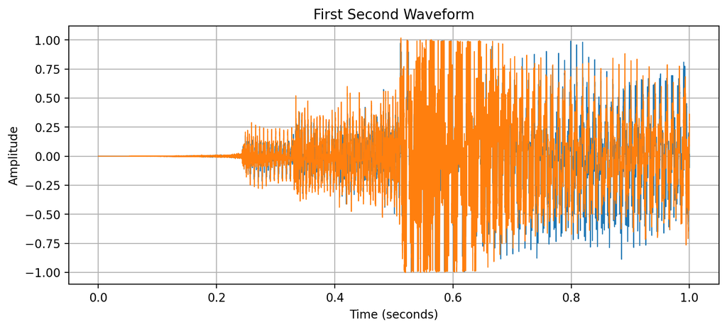

```python
plotWaveform(firstSecond, "First Second Waveform", samplerate)
```

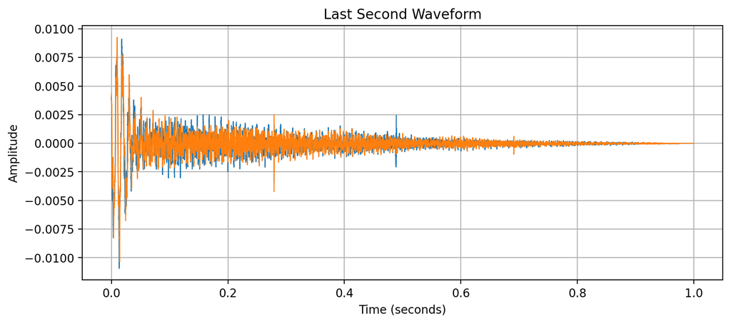

```python
plotWaveform(lastSecond, "Last Second Waveform", samplerate)
```

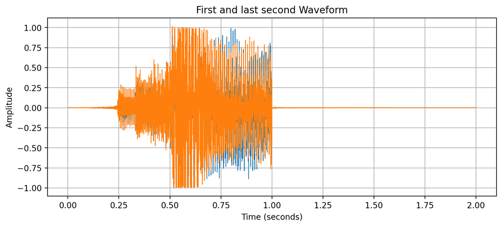

```python
plotWaveform(combined, "First and last second Waveform", samplerate)
```

## RESHAPING IN NUMPY

### 1. Create a 2D array of shape (3, 5). Flatten it into a 1D array and then reshape it back into a (5, 3) array.

```python
#1
testArray = np.random.randint(1,11,size = (3,5))
print("Original array: \n" , testArray)
testArray = testArray.reshape(-1)
print("Flattened array:", testArray)
testArray = testArray.reshape(5,3)
print("Reshaped array:\n",testArray)
```

```
Original array:
 [[ 4  2  9 10 10]
 [ 8  5  9  8  7]
 [ 2  5  1  2  8]]
Flattened array: [ 4  2  9 10 10  8  5  9  8  7  2  5  1  2  8]
Reshaped array:
 [[ 4  2  9]
 [10 10  8]
 [ 5  9  8]
 [ 7  2  5]
 [ 1  2  8]]
```

### 2.

```python
arr = np.array([1, 2, 3, 4, 5])
arr = arr.reshape(5,1)
print("Reshaped array:\n",arr)

arr = arr.reshape(5,)
print("Changed to (5,):\n",arr)

arr = arr.reshape(1,5)
print("Changed to (1,5):\n", arr)
```

```
Reshaped array:
 [[1]
 [2]
 [3]
 [4]
 [5]]
Changed to (5,):
 [1 2 3 4 5]
Changed to (1,5):
 [[1 2 3 4 5]]
```

### 3. Create a 1D NumPy array with values ranging from 1 to 100. Reshape it into a (10, 10) matrix. Apply '.ravel()' and '.flatten()' on the matrix and modify the original matrix. Compare the outputs of both methods and explain the difference in memory sharing.

```python
testArray = np.array(range(1,101))
print("Original array:\n",testArray)
matrix = testArray.reshape(10,10)
print("Matrix:\n",matrix)
```

```
Original array:
 [  1   2   3   4   5   6   7   8   9  10  11  12  13  14  15  16  17  18
  19  20  21  22  23  24  25  26  27  28  29  30  31  32  33  34  35  36
  37  38  39  40  41  42  43  44  45  46  47  48  49  50  51  52  53  54
  55  56  57  58  59  60  61  62  63  64  65  66  67  68  69  70  71  72
  73  74  75  76  77  78  79  80  81  82  83  84  85  86  87  88  89  90
  91  92  93  94  95  96  97  98  99 100]
Matrix:
 [[  1   2   3   4   5   6   7   8   9  10]
 [ 11  12  13  14  15  16  17  18  19  20]
 [ 21  22  23  24  25  26  27  28  29  30]
 [ 31  32  33  34  35  36  37  38  39  40]
 [ 41  42  43  44  45  46  47  48  49  50]
 [ 51  52  53  54  55  56  57  58  59  60]
 [ 61  62  63  64  65  66  67  68  69  70]
 [ 71  72  73  74  75  76  77  78  79  80]
 [ 81  82  83  84  85  86  87  88  89  90]
 [ 91  92  93  94  95  96  97  98  99 100]]
```

```python
print(matrix.ravel())
print(matrix)
```

```
[  1   2   3   4   5   6   7   8   9  10  11  12  13  14  15  16  17  18
  19  20  21  22  23  24  25  26  27  28  29  30  31  32  33  34  35  36
  37  38  39  40  41  42  43  44  45  46  47  48  49  50  51  52  53  54
  55  56  57  58  59  60  61  62  63  64  65  66  67  68  69  70  71  72
  73  74  75  76  77  78  79  80  81  82  83  84  85  86  87  88  89  90
  91  92  93  94  95  96  97  98  99 100]
[[  1   2   3   4   5   6   7   8   9  10]
 [ 11  12  13  14  15  16  17  18  19  20]
 [ 21  22  23  24  25  26  27  28  29  30]
 [ 31  32  33  34  35  36  37  38  39  40]
 [ 41  42  43  44  45  46  47  48  49  50]
 [ 51  52  53  54  55  56  57  58  59  60]
 [ 61  62  63  64  65  66  67  68  69  70]
 [ 71  72  73  74  75  76  77  78  79  80]
 [ 81  82  83  84  85  86  87  88  89  90]
 [ 91  92  93  94  95  96  97  98  99 100]]
```

```python
print(matrix.flatten())
print(matrix)
```

```
[  1   2   3   4   5   6   7   8   9  10  11  12  13  14  15  16  17  18
  19  20  21  22  23  24  25  26  27  28  29  30  31  32  33  34  35  36
  37  38  39  40  41  42  43  44  45  46  47  48  49  50  51  52  53  54
  55  56  57  58  59  60  61  62  63  64  65  66  67  68  69  70  71  72
  73  74  75  76  77  78  79  80  81  82  83  84  85  86  87  88  89  90
  91  92  93  94  95  96  97  98  99 100]
[[  1   2   3   4   5   6   7   8   9  10]
 [ 11  12  13  14  15  16  17  18  19  20]
 [ 21  22  23  24  25  26  27  28  29  30]
 [ 31  32  33  34  35  36  37  38  39  40]
 [ 41  42  43  44  45  46  47  48  49  50]
 [ 51  52  53  54  55  56  57  58  59  60]
 [ 61  62  63  64  65  66  67  68  69  70]
 [ 71  72  73  74  75  76  77  78  79  80]
 [ 81  82  83  84  85  86  87  88  89  90]
 [ 91  92  93  94  95  96  97  98  99 100]]
```

Flatten creates a new independent copy of the original matrix.

### 4. Generate a 5x5 NumPy matrix representing pixel intensities from an image. Use slicing to extract the central 3x3 section of the matrix and flatten it. How does reshaping impact the spatial relationships of the pixels?

```
[[  6   6 120 222 192]
 [  1 147 141 203 227]
 [197  99 252 107 212]
 [ 95  45 149 205 147]
 [ 51 123  19 173 233]]
```

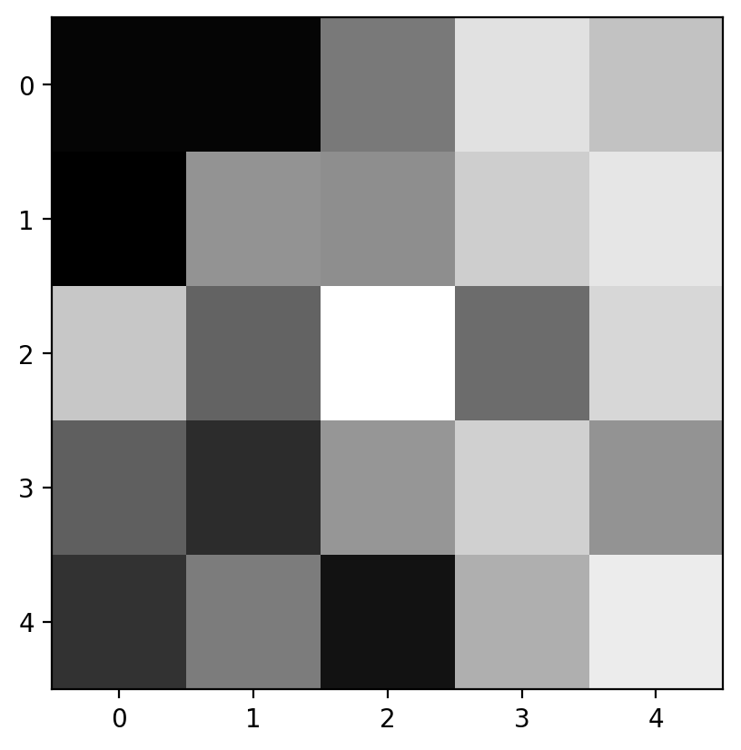

```python
imgArray = np.random.randint(0,256,size = (5,5))
print(imgArray)
plt.imshow(imgArray, cmap = "grey")
```

```python
centralArray = imgArray[1:4,1:4]
print(centralArray)
```

```
[[147 141 203]
 [ 99 252 107]
 [ 45 149 205]]
```

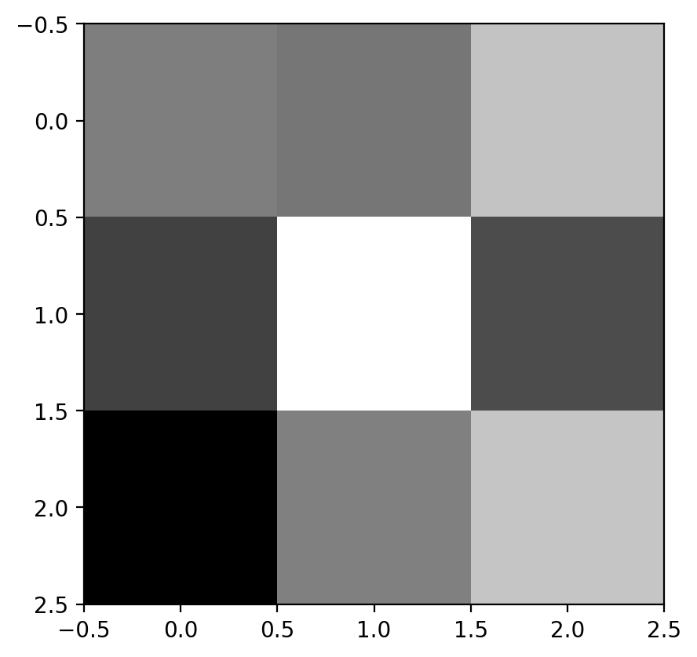

```python
plt.imshow(centralArray, cmap="grey")
```

```python
centralArray = centralArray.flatten()
print(centralArray)
```

```
[147 141 203  99 252 107  45 149 205]
```

### 5. Create a 3-channel RGB image as a NumPy array of shape (3, 4, 4) with random integer values between 0 and 255. Flatten the image using '.reshape()' and reshape it back to its original shape. Explain the order of pixel data stored and how reshaping affects the channel structure.

```
Original array:
 [[[189 186  97 255]
  [ 87 180 239  55]
  [ 94  58  28 157]
  [157 112 111 188]]

 [[214   7  40 225]
  [210 112 178 220]
  [ 35  46 119  39]
  [112 102 194  73]]

 [[ 78 207  90  16]
  [122 242  71 247]
  [183 158  51  21]
  [166 124 152  90]]]
```

```python
imgArray = np.random.randint(0,256,size = (3,4,4))
print("Original array:\n", imgArray)
```

```python
imgArray = imgArray.reshape(-1)
print(imgArray)
```

```
[189 186  97 255  87 180 239  55  94  58  28 157 157 112 111 188 214   7
  40 225 210 112 178 220  35  46 119  39 112 102 194  73  78 207  90  16
 122 242  71 247 183 158  51  21 166 124 152  90]
```

```python
imgArray =imgArray.reshape(3,4,4)
print(imgArray)
```

```
[[[189 186  97 255]
  [ 87 180 239  55]
  [ 94  58  28 157]
  [157 112 111 188]]

 [[214   7  40 225]
  [210 112 178 220]
  [ 35  46 119  39]
  [112 102 194  73]]

 [[ 78 207  90  16]
  [122 242  71 247]
  [183 158  51  21]
  [166 124 152  90]]]
```

Original matrix is a (3,4,4) array, where the 3 channels contain pixel brightness values for RGB. it gets flattened row - wise into a 1D array, and the reverse procedure is followed when it is converted back to (3,4,4). So the pixel values for each channel remain unaltered.

## UNIVERSAL FUNCTIONS

### Given an array x = [1, 4, 9, 16, 25], compute the square root of each element in the array and print the result.

```python
x = np.array([1, 4, 9, 16, 25])
print(np.sqrt(x))
```

```
[1. 2. 3. 4. 5.]
```

### Create an array angles =[0, π/2 , π , 3π/2 ] , calculate the sine of each angle and print the result.

```python
angles = np.array([0,np.pi/2,np.pi,3*np.pi/2])
print(angles)
print(np.sin(angles))
```

```
[0.         1.57079633 3.14159265 4.71238898]
[ 0.0000000e+00  1.0000000e+00  1.2246468e-16 -1.0000000e+00]
```

### Given two arrays a =[True, False, True] and b = [False, False, True], perform an element-wise logical AND operation and print the result.

```python
a = np.array([True,False,True])
b = np.array([False,False,True])
print(np.logical_and(a,b))
```

```
[False False  True]
```

### Create two arrays x = [1, 2, 3, 4] and y = [2, 2, 3, 5], perform an element-wise comparison (x < y) and print the result.

```python
x = np.array([1,2,3,4])
y = np.array([2,2,3,5])
print(x<y)
```

```
[ True False False  True]
```

### Create an array x =[-2, -1, 0, 1, 2, 3, 4], compute the following element-wise operation:

If an element is negative, square it. If an element is non-negative, compute its exponential. Print the resulting array.

```python
x = np.array([-2,-1,0,1,2,3,4])
print(np.concatenate([np.square(x[x<0]),np.power(np.e,x[x>=0])]))
```

```
[ 4.          1.          1.          2.71828183  7.3890561  20.08553692
 54.59815003]
```

## AGGREGATIONS

### 1. Generate a random array of size 10.

calculate the following:

Print the array The sum of all elements. The mean of the array. The standard deviation. Find 5 ∗ Minimum -3 ∗ Maximum

```python
testArray = np.random.randint(1,11,10)
print(testArray)
```

```
[ 3 10  9  9  2  9  8  6  6  2]
```

```python
print(np.sum(testArray))
```

```
64
```

```python
print(np.mean(testArray))
```

```
6.4
```

```python
print(np.std(testArray))
```

```
2.9393876913398134
```

```python
minim = np.min(testArray)
maxim = np.max(testArray)
print(5*minim - 3*maxim)
```

```
-20
```

### 2. Generate a 4x5 matrix with random integers between 1 and 50.

Print the matrix. Compute the mean of all elements in the matrix. Compute the sum of each row in the matrix.

```python
matrix = np.random.randint(1,51,size = (4,5))
print(matrix)
```

```
[[50 44 24  7 43]
 [29 18 39 49  7]
 [36 32 47 21 33]
 [ 1 26 32 45 48]]
```

```python
print(np.mean(matrix))
```

```
31.55
```

```python
print(np.sum(matrix, axis=1))
```

```
[168 142 169 152]
```

### 3. Generate a random 3x3 matrix with random integers between 1 to 10

Find the minimum value in each column and store it in a separate list min. Find the maximum value in each row and store it in a separate list max. Find the value of minimum of list max - maximum of list min.

```python
randomMatrix = np.random.randint(1,11,size = (3,3))
print(randomMatrix)
```

```
[[10  9  4]
 [ 8  7  3]
 [ 8 10  8]]
```

```python
maxRow = np.max(randomMatrix, axis = 1)
print(maxRow)
```

```
[10  8 10]
```

```python
minCol = np.min(randomMatrix, axis=0)
print(minCol)
```

```
[8 7 3]
```

```python
print(np.min(maxRow) - np.max(minCol))
```

```
0
```

### 4. Given the array : data = np.array([15, 25, 35, 45, 55, 65]):

Find the minimum value. Subtract this minimum value from all elements of the array and then calculate the mean of the resulting array.

```python
data = np.array([15, 25, 35, 45, 55, 65])
minim = np.min(data)
print("minimum value is:",minim)
data -= minim
print(data)
print(np.mean(data))
```

```
minimum value is: 15
[ 0 10 20 30 40 50]
25.0
```

### 5. Given the array : arr = np.array([3, 5, 7, 9, 11]):

Compute the cumulative sum of the elements. Compute the cumulative product of the elements.

```python
arr = np.array([3, 5, 7, 9, 11])
print(np.cumsum(arr))
print(np.cumprod(arr))
```

```
[ 3  8 15 24 35]
[    3    15   105   945 10395]
```

### 6. Imagine you have a dataset representing the scores of 4 students in 3 subjects:

```python
scores = np.array([[85, 92, 78], [88, 76, 95], [91, 89, 82], [75, 85, 88]])
print("Average of each student:", np.mean(scores, axis = 1))
```

```
Average of each student: [85.         86.33333333 87.33333333 82.66666667]
```

```python
print("Average of each subject is:", np.mean(scores, axis = 0))
```

```
Average of each subject is: [84.75 85.5  85.75]
```

```python
print("Overall average score is:", np.mean(scores))
```

```
Overall average score is: 85.33333333333333
```

## BROADCASTING IN NUMPY

### 1. Given two arrays:

A = np.array([[1, 2, 3], [4, 5, 6], [7, 8, 9]]) (shape: (3, 3)) B = np.array([10, 20, 30]) (shape: (3,)) Perform elementwise addition of A and B using broadcasting and print the result.

What is the resulting shape?

```python
A = np.array([[1, 2, 3], [4, 5, 6], [7, 8, 9]])
B = np.array([10,20,30])
result = A+B
print(result)
print("Resulting Shape:",result.shape)
```

```
[[11 22 33]
 [14 25 36]
 [17 28 39]]
Resulting Shape: (3, 3)
```

### 2. Write a function check_broadcasting(shape1, shape2) that:

Accepts two shapes as input and checks if they are broadcast-compatible. Use the function to test the following shape pairs: (3, 4) and (4,) (2, 1, 5) and (3, 5) (2, 3) and (2,)

For each case:

State whether broadcasting is possible.

If possible, state the resulting shape of the operation

```python
def check_broadcasting(shape1,shape2):
    try:
        A = np.zeros(shape = shape1)
        B = np.zeros(shape = shape2)
        trial = A + B
        print(trial.shape)
        return True
    except:
        return False
```

```python
check_broadcasting((3,4), (4,))
```

```
(3, 4)
```

```
True
```

```python
check_broadcasting((2,1,5),(3,5))
```

```
(2, 3, 5)
```

```
True
```

```python
check_broadcasting((2,3), (2,))
```

```
False
```

### 3. Create a 2D array A of shape (3, 5) with random integers between 1 and 10.

```python
A = np.random.randint(1,11,size = (3,5))
B = np.random.randint(1,6, size = (5,))
```

### 4. Create a 3D array A with shape (2, 4, 3) filled with random integers between 0 and 10.

Create an array B of shape (4, 3) containing a constant value of 5. Use broadcasting to add B to each 2D array slice of A. Print the result

```python
A = np.random.randint(0,11,size = (2,4,3))
print(A)
```

```
[[[ 4  6  3]
  [ 8  4  3]
  [ 6  7  1]
  [ 1  3  2]]

 [[ 2  4  0]
  [ 8  6  1]
  [ 6  9  3]
  [ 4  9 10]]]
```

```python
B = np.tile(5 ,(4,3))
print(B)
```

```
[[5 5 5]
 [5 5 5]
 [5 5 5]
 [5 5 5]]
```

```python
print(A + B)
```

```
[[[ 9 11  8]
  [13  9  8]
  [11 12  6]
  [ 6  8  7]]

 [[ 7  9  5]
  [13 11  6]
  [11 14  8]
  [ 9 14 15]]]
```

### 5. You are given a grayscale image of shape (32, 32), where each pixel value is an integer. You want to apply a scaling factor of 0.5 to all the pixel values using broadcasting.

Use broadcasting to scale the image by multiplying it with the scaling factor 0.5. Verify that the pixel values of the image are halved by printing the scaled image.

```
[[ 96 180 204 ... 220   2 254]
 [134 198 135 ... 159 232 150]
 [233 174  70 ... 157  58 120]
 ...
 [221  58  86 ...  69  18  50]
 [ 35 233 246 ...  82 217 197]
 [203 215  45 ...   9  97 135]]
```

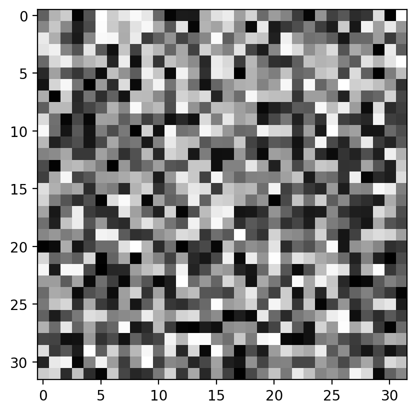

```python
randomImage = np.random.randint(0,256, size = (32,32))
print(randomImage)
plt.imshow(randomImage, cmap="grey")
```

```python
scaledImage = randomImage*0.5
```

```python
print(scaledImage)
```

```
[[ 48.   90.  102.  ... 110.    1.  127. ]
 [ 67.   99.   67.5 ...  79.5 116.   75. ]
 [116.5  87.   35.  ...  78.5  29.   60. ]
 ...
 [110.5  29.   43.  ...  34.5   9.   25. ]
 [ 17.5 116.5 123.  ...  41.  108.5  98.5]
 [101.5 107.5  22.5 ...   4.5  48.5  67.5]]
```

### 6. Calculate the distance between an observation point and a set of code points (codes). The goal is to find the closest code to the observation by calculating the Euclidean distance between each code and the observation.

Given two arrays : codes = np.array([ [1.0, 2.0, 3.0], [4.0, 5.0, 6.0], [7.0, 8.0, 9.0], [1.0, 1.0, 1.0], [2.0, 3.0, 4.0] ])

observation = np.array([3.0, 3.0, 3.0])

Use broadcasting to calculate the squared Euclidean distance between the observation and each code. Find and print the index of the closest code to the observation. Print the distance between the observation and the closest code.

```python
codes = np.array([ [1.0, 2.0, 3.0], [4.0, 5.0, 6.0], [7.0, 8.0, 9.0], [1.0, 1.0, 1.0], [2.0, 3.0, 4.0] ])
observation = np.array([3.0, 3.0, 3.0])
```

```python
squared_distances = np.sum((codes - observation) ** 2, axis=1)
closest_index = np.argmin(squared_distances)
closest_distance = np.sqrt(squared_distances[closest_index])
```

```python
print(f"Index of the closest code: {closest_index}")
print(f"Distance to the closest code: {closest_distance:.4f}")
```

```
Index of the closest code: 4
Distance to the closest code: 1.4142
```

## CONCATENATION

### 1. Write a program to vertically stack arrays using np.vstack and print the result: (Use any three 1D arrays)

```python
testArray1 = np.random.randint(1,6,3)
testArray2 = np.random.randint(1,6,3)
testArray3 = np.random.randint(1,6,3)
testArray = np.vstack((testArray1,testArray2,testArray3))
print(testArray)
```

```
[[5 5 1]
 [5 1 4]
 [4 3 2]]
```

### 2. Write a program to horizontally stack arrays using np.hstack. Print the result: (Use any three 1D arrays)

```python
testArray1 = np.random.randint(1,6,3)
testArray2 = np.random.randint(1,6,3)
testArray3 = np.random.randint(1,6,3)
testArray = np.hstack((testArray1,testArray2,testArray3))
print(testArray)
```

```
[2 5 2 4 1 3 5 2 2]
```

### 3. Given two 2D arrays of the same row size, horizontally stack them using np.hstack and print the result

```python
m = np.array([[2, 4], [3, 6]])
n = np.array([[4, 8], [5, 10]])
print(np.hstack((m,n)))
```

```
[[ 2  4  4  8]
 [ 3  6  5 10]]
```

### 4. Using np.vstack, stack the following arrays vertically and print the results

```python
a = np.array([11, 12, 13])
b = np.array([[14, 15, 16], [17, 18, 19]])
print(np.vstack((a,b)))
```

```
[[11 12 13]
 [14 15 16]
 [17 18 19]]
```

### 5. Concatenate the following 2D arrays along different axes using np.concatenate. Demonstrate how to concatenate them along axis 0 and axis 1

```python
x = np.array([[1, 2], [3, 4]])
y = np.array([[5, 6], [7, 8]])
z = np.array([[9, 10], [11, 12]])

print(np.concatenate((x,y,z), axis = 1))
```

```
[[ 1  2  5  6  9 10]
 [ 3  4  7  8 11 12]]
```

```python
print(np.concatenate((x,y,z), axis = 0))
```

```
[[ 1  2]
 [ 3  4]
 [ 5  6]
 [ 7  8]
 [ 9 10]
 [11 12]]
```

## BOOLEAN MASKING

### 1. Use Boolean masking to filter elements from a 1D array: Write a program to create a 1D array and use Boolean masking to filter out all elements greater than 5.

```python
testArray = np.random.randint(0,256, 100)
print(testArray[testArray>5])
```

```
[126 148 186 205  18 180  26 154 129 203 104  27 108 115 134 145 232 185
  21  16 199 134 100  84 135  35 220 137  96 245 148 101 133 137  82 137
  69 111 168  53  60  48  87  85  34   7 199 177 136 167 203 243 140 125
  63  86 227 102 106  73  68 198  72 209 108  15 117  63 223   7  36 197
 205 109  38  99 230 255  39 209 112 191  13 250 193  77 109 177 153  31
 205 222   8 245 187  57   8 239]
```

### 2. Apply a Boolean mask to a 2D array: Given the 2D array below, create a Boolean mask to select all elements greater than 10 and print the masked elements.

```python
arr = np.array([[5, 12, 18], [7, 1, 3], [11, 6, 14]])
print(arr>10)
print(arr[arr>10])
```

```
[[False  True  True]
 [False False False]
 [ True False  True]]
[12 18 11 14]
```

### 3. Create a Boolean mask using a condition on an array: Create a 1D array of integers from 0 to 10. Use a Boolean mask to filter out all even numbers and print the result.

```python
arr = np.arange(11)
print(arr[arr%2 != 0])
```

```
[1 3 5 7 9]
```

### 4. Combine Boolean masks using logical operations: Given the array below, create and combine two Boolean masks:

One mask selects elements greater than 5. The other mask selects elements divisible by 3. Combine the masks using logical AND and print the result.

```python
arr = np.array([1, 3, 6, 9, 12, 15])
greaterThan5 = arr>5
divisibleBy3 = arr%3 == 0
print(greaterThan5)
print(divisibleBy3)
mask = np.logical_and(greaterThan5,divisibleBy3)
print(arr[mask])
```

```
[False False  True  True  True  True]
[False  True  True  True  True  True]
[ 6  9 12 15]
```

### 5. Mask elements in a 2D array and replace them: Write a program to replace all elements less than 5 in the 2D array below with 0 using Boolean masking.

```python
testArray = np.random.randint(1,11,size = (10,10))
print("Original Array:\n", testArray)
testArray[testArray<5] = 0
print("Modified Array:\n",testArray)
```

```
Original Array:
 [[ 4  3  8  4  5 10  1  2  5  7]
 [ 8  2  5  8  1  8  2  5  6  4]
 [ 1  4  8  9  8  9  4  6 10  7]
 [ 9  1  8  6  4  9  2  3  9  8]
 [ 6  8  7  3  9  6  9  7  9  2]
 [ 8  6  9  1  7  7  5  5  7  8]
 [10  6  2  1  4  9  9  4 10  1]
 [10  8  8  7  2  2  9  5  3 10]
 [ 2  4 10  2  9  3 10  5 10  9]
 [ 3  3  9  3  9  8  3  7  1  6]]
Modified Array:
 [[ 0  0  8  0  5 10  0  0  5  7]
 [ 8  0  5  8  0  8  0  5  6  0]
 [ 0  0  8  9  8  9  0  6 10  7]
 [ 9  0  8  6  0  9  0  0  9  8]
 [ 6  8  7  0  9  6  9  7  9  0]
 [ 8  6  9  0  7  7  5  5  7  8]
 [10  6  0  0  0  9  9  0 10  0]
 [10  8  8  7  0  0  9  5  0 10]
 [ 0  0 10  0  9  0 10  5 10  9]
 [ 0  0  9  0  9  8  0  7  0  6]]
```

### 6. Count elements satisfying a condition using Boolean masks: Write a program to count how many elements in the array below are greater than 5.

```python
testArray = np.random.randint(0,11, 100)
maskArray = testArray[testArray>5]
print(maskArray.size)
```

```
52
```